# Change-point report

July 31, 2024

This document provides a summary of the change-point analysis for AMI, broken down by men and women

# Male visits

The following section summarizes change-point analysis for trends in the number of SSD-related visits prior to the index diagnosis for men

## Results

The following summarizes the results across the various change-point approaches applied to trends in SSD-related visits.

#### Optimal Change-point(s)

The optimal model was CUSUM quad w/ periodicity

The following is a summary of the *estimated* (from given method) and *implied* (from prediction-bound) change-points for the optimal model, along with the corresponding number of missed opportunities:

| label | Change Point | Pred. Bound CP | CP # Miss | PB CP # Miss |
| --- | --- | --- | --- | --- |
| CUSUM quad w/ periodicity | 126 | 56 | 151548.2 | 135361.6 |

The following is a plot of the optimal model(s). The red line depicts the estimated expected trend, the dashed-black line depicts the estimated change-point and the dashed-green line depicts the implied change-point from the prediction bound approach:

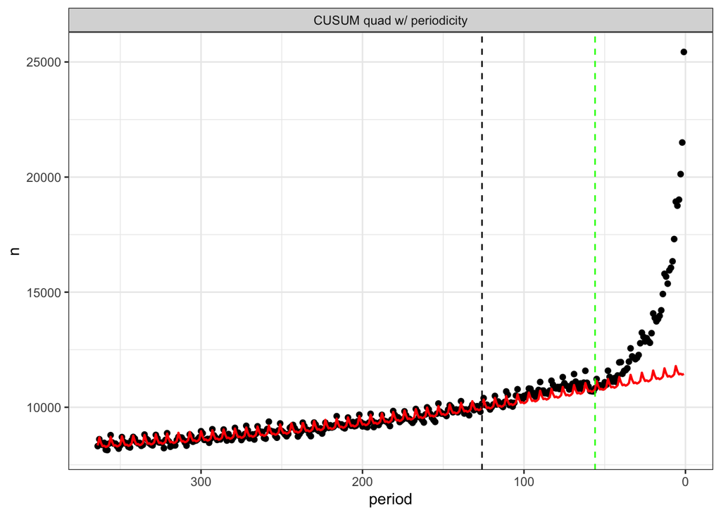

#### Change-point summary

The following is a summary of the estimated change-point and the implied change-point using the prediction bound approach along with the corresponding number of missed opportunities for each change-point, across each of the methods evaluated:

| label | Change Point | Pred. Bound CP | CP # Miss | PB CP # Miss |
| --- | --- | --- | --- | --- |
| Piecewise lm w/ periodicity | 25 | 48 | 114269.06 | 130062.82 |
| Piecewise lm | 25 | 42 | 113846.50 | 129184.93 |
| Piecewise quad w/ periodicity | 29 | 41 | 103934.61 | 108175.70 |
| Piecewise quad | 29 | 38 | 103915.11 | 107486.89 |
| Piecewise cubic w/ periodicity | 32 | 38 | 101006.38 | 102724.10 |
| Piecewise cubic | 31 | 36 | 99280.84 | 101408.12 |
| Piecewise exp w/ periodicity | 29 | 35 | 56166.59 | 56722.45 |
| Piecewise exp | 31 | 29 | 56358.16 | 56358.16 |
| CUSUM lm w/ periodicity | 126 | 130 | 206596.15 | 207227.99 |
| CUSUM lm | 126 | 126 | 207527.07 | 207527.07 |
| CUSUM quad w/ periodicity | 126 | 56 | 151548.21 | 135361.57 |
| CUSUM quad | 126 | 56 | 153423.77 | 135999.46 |
| CUSUM cubic w/ periodicity | 126 | 48 | 137567.50 | 124726.85 |
| CUSUM cubic | 126 | 50 | 151005.40 | 133573.71 |
| CUSUM exp w/ periodicity | 126 | 29 | 53775.98 | 49154.39 |
| CUSUM exp | 126 | 21 | 57994.83 | 47855.85 |

#### Performance Summary

The following is a summary of the performance metrics for each of the change-point approaches:

| label | Change Point | Pred. Bound CP | CP Consisency | MSE | MSE 7-day | MSE 14-day |
| --- | --- | --- | --- | --- | --- | --- |
| Piecewise lm w/ periodicity | 25 | 48 | -92.000000 | 96735.78 | 1917241.27 | 1265024.24 |
| Piecewise lm | 25 | 42 | -68.000000 | 125041.20 | 1998359.75 | 1338050.22 |
| Piecewise quad w/ periodicity | 29 | 41 | -41.379310 | 19474.79 | 315928.45 | 177335.07 |
| Piecewise quad | 29 | 38 | -31.034483 | 44100.23 | 342296.00 | 204645.31 |
| Piecewise cubic w/ periodicity | 32 | 38 | -18.750000 | 14236.17 | 126434.44 | 79456.91 |
| Piecewise cubic | 31 | 36 | -16.129032 | 40803.54 | 195225.07 | 137627.56 |
| Piecewise exp w/ periodicity | 29 | 35 | -20.689655 | 17422.02 | 17596.17 | 25244.05 |
| Piecewise exp | 31 | 29 | 6.451613 | 43018.21 | 67213.30 | 86729.13 |
| CUSUM lm w/ periodicity | 126 | 130 | -3.174603 | 12810.38 | 37176.77 | 28286.41 |
| CUSUM lm | 126 | 126 | 0.000000 | 33254.69 | 32423.74 | 39070.96 |
| CUSUM quad w/ periodicity | 126 | 56 | 55.555556 | 8324.76 | 16568.38 | 12610.99 |
| CUSUM quad | 126 | 56 | 55.555556 | 29514.42 | 14959.71 | 25780.06 |
| CUSUM cubic w/ periodicity | 126 | 48 | 61.904762 | 7614.82 | 18727.83 | 13291.49 |
| CUSUM cubic | 126 | 50 | 60.317460 | 29516.65 | 14957.02 | 25807.31 |
| CUSUM exp w/ periodicity | 126 | 29 | 76.984127 | 7104.09 | 18598.18 | 12999.44 |
| CUSUM exp | 126 | 21 | 83.333333 | 29641.08 | 15795.11 | 26753.58 |

#### Change-point rankings

The following is a ranking of change-point methods in terms of their consistency with the implied change-point from the prediction-bound approach, overall MSE before the change-point and MSE within 7 and 14 days prior to the change-point.

| label | Change Point | Pred. Bound CP | Average Rank | consistency_rank | mse_rank | mse7_rank | mse14_rank |
| --- | --- | --- | --- | --- | --- | --- | --- |
| CUSUM quad w/ periodicity | 126 | 56 | 4.25 | 9 | 3 | 4 | 1 |
| Piecewise exp w/ periodicity | 29 | 35 | 5.25 | 6 | 6 | 5 | 4 |
| CUSUM exp w/ periodicity | 126 | 29 | 5.50 | 13 | 1 | 6 | 2 |
| CUSUM lm w/ periodicity | 126 | 130 | 5.75 | 2 | 4 | 9 | 8 |
| CUSUM cubic w/ periodicity | 126 | 48 | 5.75 | 11 | 2 | 7 | 3 |
| CUSUM quad | 126 | 56 | 6.00 | 9 | 8 | 2 | 5 |
| CUSUM cubic | 126 | 50 | 6.50 | 10 | 9 | 1 | 6 |
| CUSUM lm | 126 | 126 | 7.25 | 1 | 11 | 8 | 9 |
| Piecewise cubic w/ periodicity | 32 | 38 | 7.75 | 5 | 5 | 11 | 10 |
| CUSUM exp | 126 | 21 | 8.50 | 14 | 10 | 3 | 7 |
| Piecewise exp | 31 | 29 | 9.25 | 3 | 13 | 10 | 11 |
| Piecewise cubic | 31 | 36 | 10.00 | 4 | 12 | 12 | 12 |
| Piecewise quad w/ periodicity | 29 | 41 | 10.25 | 8 | 7 | 13 | 13 |
| Piecewise quad | 29 | 38 | 12.25 | 7 | 14 | 14 | 14 |
| Piecewise lm w/ periodicity | 25 | 48 | 15.00 | 15 | 15 | 15 | 15 |
| Piecewise lm | 25 | 42 | 15.00 | 12 | 16 | 16 | 16 |

## Plots

### Piecewise models with periodicity

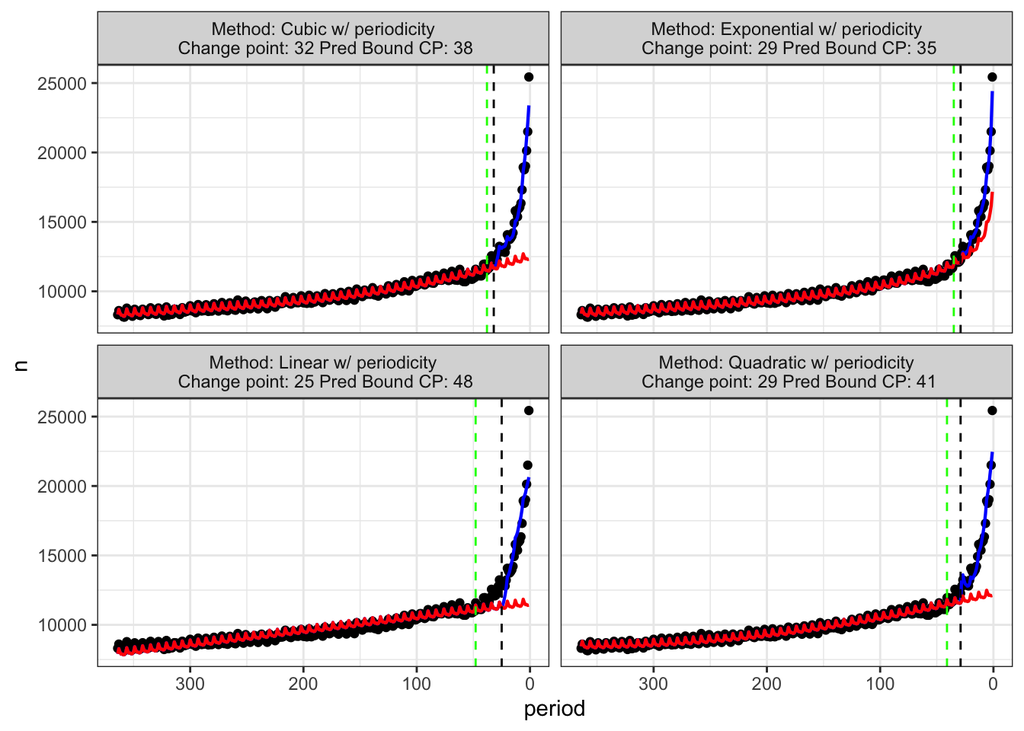

### Piecewise models without periodicity

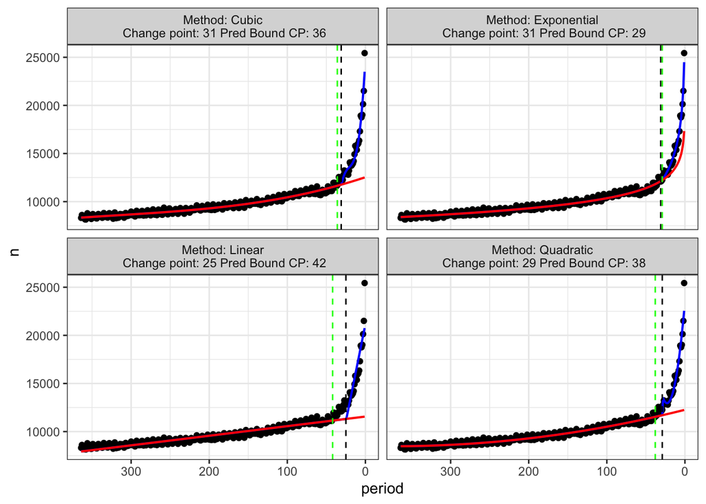

### CUSUM models with periodicity

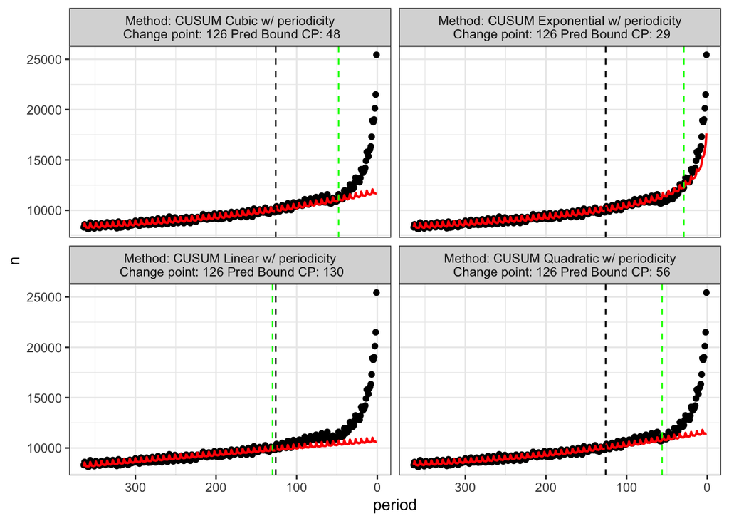

### CUSUM models without periodicity

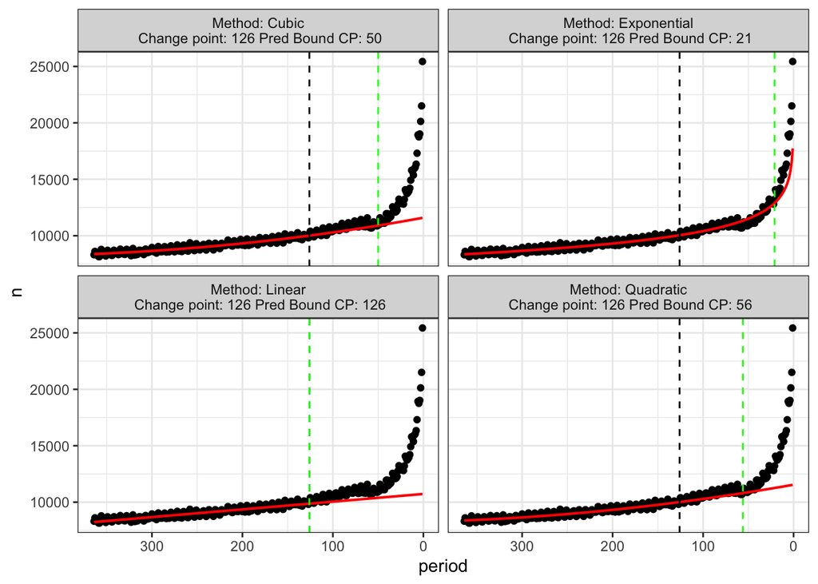

# Female Visits

The following section summarizes change-point analysis for trends in the number of SSD visits for women prior to the index diagnosis

## Results

The following summarizes the results across the various change-point approaches applied to trends in SSD-related visits.

#### Optimal Change-point(s)

The optimal model was CUSUM lm w/ periodicity

The following is a summary of the *estimated* (from given method) and *implied* (from prediction-bound) change-points for the optimal model, along with the corresponding number of missed opportunities:

| label | Change Point | Pred. Bound CP | CP # Miss | PB CP # Miss |
| --- | --- | --- | --- | --- |
| CUSUM lm w/ periodicity | 146 | 155 | 163729 | 164829.9 |

The following is a plot of the optimal model(s). The red line depicts the estimated expected trend, the dashed-black line depicts the estimated change-point and the dashed-green line depicts the implied change-point from the prediction bound approach:

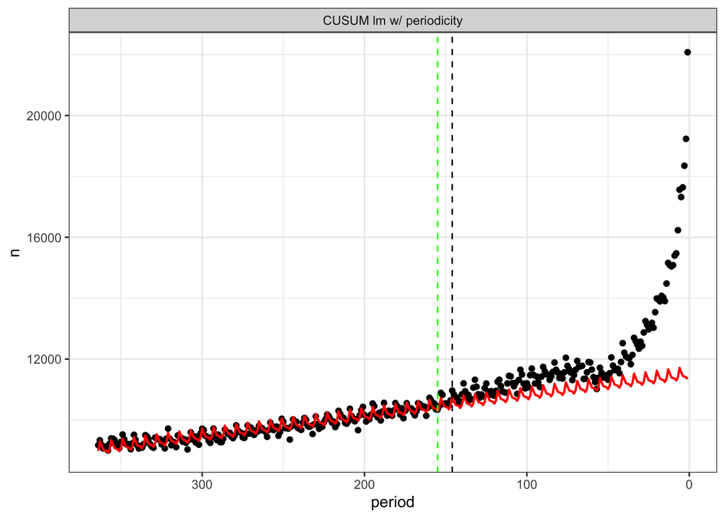

#### Change-point summary

The following is a summary of the estimated change-point and the implied change-point using the prediction bound approach along with the corresponding number of missed opportunities for each change-point, across each of the methods evaluated:

| label | Change Point | Pred. Bound CP | CP # Miss | PB CP # Miss |
| --- | --- | --- | --- | --- |
| Piecewise lm w/ periodicity | 26 | 42 | 83999.30 | 92108.88 |
| Piecewise lm | 26 | 35 | 83710.02 | 90119.72 |
| Piecewise quad w/ periodicity | 29 | 35 | 75884.69 | 77666.33 |
| Piecewise quad | 29 | 35 | 75814.28 | 77808.47 |
| Piecewise cubic w/ periodicity | 32 | 41 | 81127.04 | 82875.05 |
| Piecewise cubic | 31 | 35 | 79596.74 | 81261.82 |
| Piecewise exp w/ periodicity | 60 | 14 | 13940.90 | 13880.67 |
| Piecewise exp | 60 | 14 | 14072.87 | 13845.23 |
| CUSUM lm w/ periodicity | 146 | 155 | 163729.05 | 164829.91 |
| CUSUM lm | 146 | 56 | 164135.80 | 123993.22 |
| CUSUM quad w/ periodicity | 146 | 42 | 95656.29 | 83618.12 |
| CUSUM quad | 146 | 35 | 96005.59 | 81241.70 |
| CUSUM cubic w/ periodicity | 146 | 48 | 117497.40 | 98755.66 |
| CUSUM cubic | 146 | 42 | 122576.11 | 100487.98 |
| CUSUM exp w/ periodicity | 146 | 13 | 15162.79 | 10934.36 |
| CUSUM exp | 146 | 9 | 18503.06 | 10249.04 |

#### Performance Summary

The following is a summary of the performance metrics for each of the change-point approaches:

| label | Change Point | Pred. Bound CP | CP Consisency | MSE | MSE 7-day | MSE 14-day |
| --- | --- | --- | --- | --- | --- | --- |
| Piecewise lm w/ periodicity | 26 | 42 | -61.538461 | 45126.25 | 714233.25 | 434075.30 |
| Piecewise lm | 26 | 35 | -34.615385 | 68757.99 | 773174.85 | 492460.77 |
| Piecewise quad w/ periodicity | 29 | 35 | -20.689655 | 16674.44 | 118100.95 | 64510.82 |
| Piecewise quad | 29 | 35 | -20.689655 | 38923.99 | 131133.49 | 92153.29 |
| Piecewise cubic w/ periodicity | 32 | 41 | -28.125000 | 14588.03 | 78579.17 | 52435.98 |
| Piecewise cubic | 31 | 35 | -12.903226 | 38078.44 | 137151.45 | 111773.10 |
| Piecewise exp w/ periodicity | 60 | 14 | 76.666667 | 12041.36 | 125268.15 | 80361.12 |
| Piecewise exp | 60 | 14 | 76.666667 | 32317.12 | 150383.18 | 103000.00 |
| CUSUM lm w/ periodicity | 146 | 155 | -6.164384 | 10678.09 | 25962.51 | 18374.92 |
| CUSUM lm | 146 | 56 | 61.643836 | 27112.26 | 51558.96 | 44634.12 |
| CUSUM quad w/ periodicity | 146 | 42 | 71.232877 | 7322.11 | 4092.46 | 4090.85 |
| CUSUM quad | 146 | 35 | 76.027397 | 23935.85 | 29441.45 | 30183.40 |
| CUSUM cubic w/ periodicity | 146 | 48 | 67.123288 | 6947.28 | 4521.53 | 4013.36 |
| CUSUM cubic | 146 | 42 | 71.232877 | 23814.40 | 30767.77 | 30773.90 |
| CUSUM exp w/ periodicity | 146 | 13 | 91.095890 | 7155.50 | 3191.16 | 3346.60 |
| CUSUM exp | 146 | 9 | 93.835616 | 24213.21 | 29361.29 | 30050.49 |

#### Change-point rankings

The following is a ranking of change-point methods in terms of their consistency with the implied change-point from the prediction-bound approach, overall MSE before the change-point and MSE within 7 and 14 days prior to the change-point.

| label | Change Point | Pred. Bound CP | Average Rank | consistency_rank | mse_rank | mse7_rank | mse14_rank |
| --- | --- | --- | --- | --- | --- | --- | --- |
| CUSUM lm w/ periodicity | 146 | 155 | 3.25 | 1 | 4 | 4 | 4 |
| CUSUM cubic w/ periodicity | 146 | 48 | 3.50 | 8 | 1 | 3 | 2 |
| CUSUM exp w/ periodicity | 146 | 13 | 4.00 | 12 | 2 | 1 | 1 |
| CUSUM quad w/ periodicity | 146 | 42 | 4.25 | 9 | 3 | 2 | 3 |
| Piecewise cubic w/ periodicity | 32 | 41 | 7.00 | 4 | 6 | 9 | 9 |
| Piecewise quad w/ periodicity | 29 | 35 | 7.50 | 3 | 7 | 10 | 10 |
| CUSUM quad | 146 | 35 | 7.75 | 10 | 9 | 6 | 6 |
| CUSUM cubic | 146 | 42 | 7.75 | 9 | 8 | 7 | 7 |
| CUSUM exp | 146 | 9 | 8.25 | 13 | 10 | 5 | 5 |
| CUSUM lm | 146 | 56 | 8.50 | 7 | 11 | 8 | 8 |
| Piecewise exp w/ periodicity | 60 | 14 | 9.50 | 11 | 5 | 11 | 11 |
| Piecewise quad | 29 | 35 | 10.25 | 3 | 14 | 12 | 12 |
| Piecewise cubic | 31 | 35 | 10.50 | 2 | 13 | 13 | 14 |
| Piecewise exp | 60 | 14 | 12.50 | 11 | 12 | 14 | 13 |
| Piecewise lm w/ periodicity | 26 | 42 | 12.75 | 6 | 15 | 15 | 15 |
| Piecewise lm | 26 | 35 | 13.25 | 5 | 16 | 16 | 16 |

## Plots

### Piecewise models with periodicity

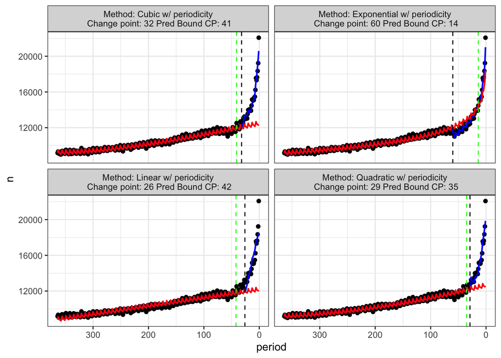

### Piecewise models without periodicity

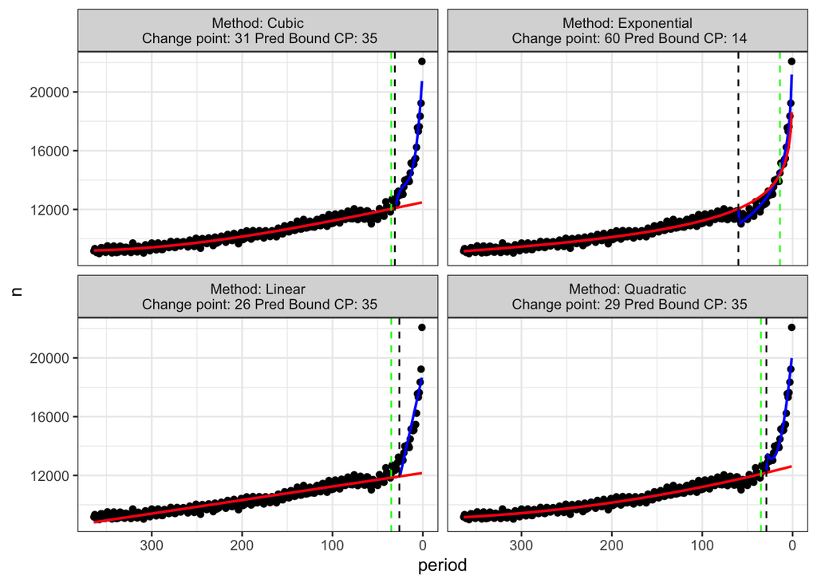

### CUSUM models with periodicity

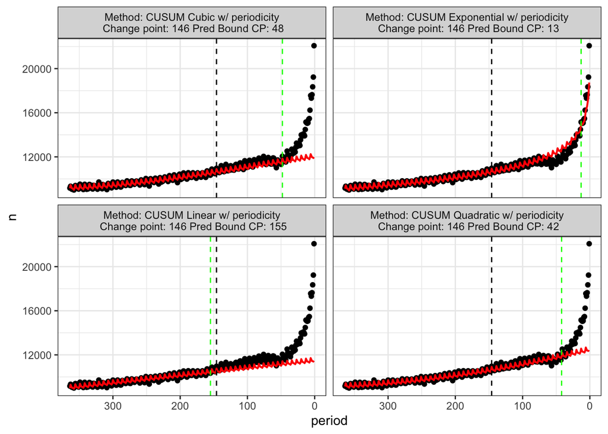

### CUSUM models without periodicity

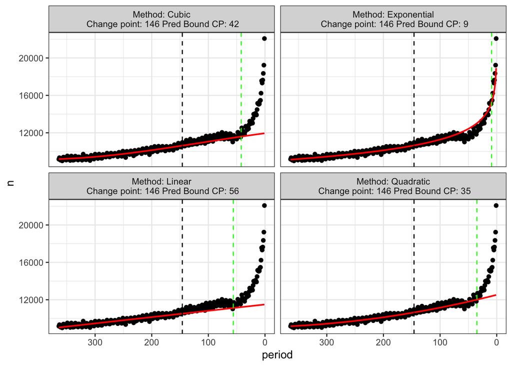